# 2018201743+张嘉辰+第二次作业

张嘉辰-2018201743

2020年10月15日

# 3.1 读入数据

第1095行，湖南省洞口县的记录中，第11列的地方一般财政预算收入多加了双引号",已提前手动修正。

```r
#空值读入的结果是空字符""
data_origin <- read.csv("D:\\data\\HW2.csv", header = TRUE, stringsAsFactors = FALSE)
#去掉第二行，第二行是各变量的单位
data <- data_origin[2:nrow(data_origin), ]
```

# 3.2 简单估计

要估计的总体参数为各县的平均地方财政预算收入，即总体均值。

采用简单估计量，即样本均值。

```r
income <- data[,11]
#将字符串转化为数字
income <- as.numeric(income)
#去除空值
income_nona <- na.omit(income)
#得到地方财政一般预算收入的均值的真实值
mean(income_nona)
```

```
## [1] 128258.7
```

```r
#抽取一个样本量为200的简单随机样本
n <- 200
N <- 2077
#设置随机数种子
set.seed(1234)
#简单随机不放回抽样
samp_income <- sample(income_nona, n, replace=FALSE)
mean_samp_income <- mean(samp_income)
#样本的均值，即总体均值的估计值
mean_samp_income
```

```
## [1] 136566.5
```

```r
#抽样比
f <- n/N
#理论的标准误差
sd_samp_income_theo <- sqrt((1-n/N)*var(income_nona)/n)
sd_samp_income_theo
```

```
## [1] 13951.55
```

```r
#样本均值的标准误
sd_samp_income <- sqrt((1-n/N)*var(samp_income)/n)
sd_samp_income
```

```
## [1] 17491.79
```

```r
#总体总值的真实值
sum_income_real <- N*mean(income_nona)
sum_income_real
```

```
## [1] 266393217
```

```r
#总体总值的估计值，即样本的总值
sum_samp_income <- N*mean_samp_income
sum_samp_income
```

```
## [1] 283648558
```

```r
#总体总值的理论的标准差
sd_sum_income <- N*sd_samp_income_theo
sd_sum_income
```

```
## [1] 28977370
```

```r
#求得总体总值的置信上限和置信下限
inter_lower_income <- sum_samp_income - qnorm(0.975)*sd_sum_income
inter_lower_income
```

```
## [1] 226853957
```

```r
inter_upper_income <- sum_samp_income + qnorm(0.975)*sd_sum_income
inter_upper_income
```

```
## [1] 340443160
```

# 3.3 估计总体的比例

要估计的总体参数为总体中拥有超过15个乡镇的县的比例。

采用简单估计量，即样本中超过15个乡镇的县的比例。

```r
#空值读入的结果是空字符""
data_origin <- read.csv("D:\\data\\HW2.csv", header = TRUE, stringsAsFactors = FALSE)
#去掉第二行，第二行是各变量的单位
data <- data_origin[2:nrow(data_origin), ]

#新构建变量if_more15，如果该县的乡镇个数大于15，则if_more15为1，否则为0
#从而将比例转化为均值
if_more15 <- rep(0,2077)
if_more15 <- ifelse(data$乡镇个数 %in% c(1:15),0,1)
#去除空值
if_more_15_nona <- na.omit(if_more15)

#拥有超过15个乡镇的比例的真实值
mean_real_more15 <- mean(if_more_15_nona)
mean_real_more15
```

```
## [1] 0.3875782
```

```r
#设置随机数种子
set.seed(1234)
#简单随机不放回抽样
samp_ifmore <- sample(if_more_15_nona, n, replace=FALSE)
mean_samp_more15 <- mean(samp_ifmore)
mean_samp_more15
```

```
## [1] 0.355
```

```r
#理论的标准误差
sd_theo_more15 <- sqrt((1-n/N)*var(if_more_15_nona)/n)
sd_theo_more15
```

```
## [1] 0.03275733
```

```r
#估计的标准误差
sd_samp_more15 <- sqrt((1-n/N)*var(samp_ifmore)/n)
sd_samp_more15
```

```
## [1] 0.03224641
```

```r
#至少拥有15个乡镇的县总数，即总值的真实值
sum_real_more15 <- sum(if_more_15_nona)
sum_real_more15
```

```
## [1] 805
```

```r
#至少拥有15个乡镇的县总数的估计值，即总值的估计值
sum_samp_if <- N*mean_samp_more15
sum_samp_if
```

```
## [1] 737.335
```

```r
#在α=0.05，绝对允许误差在2%以内的前提下，求得n0
n0 <- ((qnorm(0.975)/0.02)^2)*var(if_more_15_nona)
n0
```

```
## [1] 2280.633
```

```r
#得到满足绝对允许误差在2%以内的最小样本量n
n <- n0/(1+(n0/2077))
n
```

```
## [1] 1087.029
```

```r
#因此，最小样本量为不小于n的最小的整数，即最小样本量为1088
```

# 3.4 估计总体的比例

要估计的总体参数为总体拥有中至少一个千万元级别地方财政预算收入的乡镇的比例。

采用简单估计量，即样本中拥有至少一个千万元级别地方财政预算收入的乡镇的比例比例。

```r
n <- 200
#样本中至少一个千万元级别地方财政预算收入的乡镇的比例已知
p <- 29/200
q <- 1-p
#求得估计量的方差的估计值
var_samp_1000 <- n*p*q/(n-1)
var_samp_1000
```

```
## [1] 0.124598
```

```r
#求得估计量的标准误的估计值
f <- 200/2077
se_samp_1000 <- sqrt((1-f)*p*q/(n-1))
se_samp_1000
```

```
## [1] 0.02372763
```

# 3.5 比估计

要估计的总体参数为该年各县的平均地方财政预算收入，即总体均值。

采用比估计量，选择的辅助变量为地区生产总值。

## (1)选取辅助变量

分别计算地方财政一般预算收入与其他变量之间的相关系数，选择相关系数最大的变量作为辅助变量。

```r
#除省份和县域以外的所有变量，即所有定量变量
data_variable <- data[,3:16]
#由于读入数据后，各列的类型均为字符型，所以将其转化为数字类型
data_variable <- sapply(data_variable[,1:14],as.numeric)
data_variable <- na.omit(data_variable)
#计算相关系数
cor(data_variable)[,9]
```

```
##               行政区域面积                   乡镇个数
##                -0.07218452                 0.07426850
##                   户籍人口           第二产业从业人员
##                 0.38591161                 0.69101038
##           第三产业从业人员               地区生产总值
##                 0.53934596                 0.91017068
##             第一产业增加值             第二产业增加值
##                 0.32140326                 0.88610782
## 地方财政一般预算收入.万元.                   各项税收
##                 1.00000000                 0.88847460
## 地方财政一般预算支出.万元.           居民储蓄存款余额
##                 0.86173470                 0.83279700
##   年末金融机构各项贷款余额     规模以上工业企业单位数
##                 0.86987267                 0.84561071
```

```r
#可以看出，地区生产总值与地方财政一般预算收入之间的相关系数最大，所以选取地区生产总值作为辅助变量。
```

## (2)抽样，计算比估计的估计值

```r
n <- 200
#地区生产总值
gdp <- data[,8]
gdp <- as.numeric(gdp)
#去除空值
gdp_nona <- na.omit(gdp)
#地方财政一般预算收入变量
income <- data[,11]
income <- as.numeric(income)
#去除空值
income_nona <- na.omit(income)
#得到地方财政一般预算收入与地区生产总值之前的相关系数
cor_gdp_income <- cor(gdp_nona,income_nona)
cor_gdp_income
```

```
## [1] 0.9123418
```

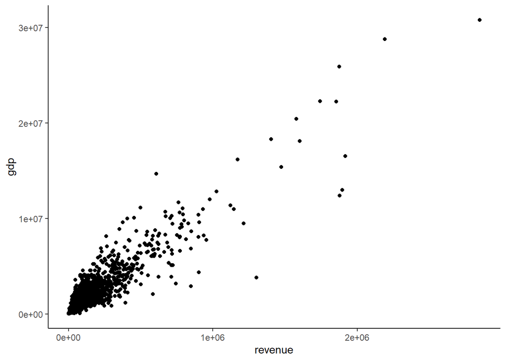

```r
#画出地方财政一般预算收入与地区生产总值之间的散点图
df <- data.frame(gdp = gdp_nona, revenue = income_nona)
library(ggplot2)
ggplot(df, aes(x = revenue, y = gdp)) + geom_point() +
  theme(panel.border = element_blank(),
        panel.grid.major = element_blank(),
        panel.grid.minor = element_blank(),
        axis.line = element_line(colour = "black"),
        axis.ticks = element_blank()) +
  theme_classic()
```

```r
#得到地区生产总值的总体均值
mean_gdp_all_X <- mean(gdp_nona)
mean_gdp_all_X
```

```
## [1] 1820416
```

```r
#设置随机数种子
set.seed(12)
#进行简单随机不放回抽样
samp_income <- sample(income_nona, n, replace=FALSE)
mean_samp_income <- mean(samp_income)
#地方财政一般预算收入的样本均值
mean_samp_income
```

```
## [1] 122640.3
```

```r
samp_gdp <- sample(gdp_nona, n, replace=FALSE)
mean_samp_gdp <- mean(samp_gdp)
#地方生产总值的样本均值
mean_samp_gdp
```

```
## [1] 1615439
```

```r
#计算比估计
mean_ratio_income <- mean_gdp_all_X*mean_samp_income/mean_samp_gdp
mean_ratio_income
```

```
## [1] 138201.7
```

```r
#R的估计值为Y的样本均值除以X的样本均值
r_est <- mean_samp_income/mean_samp_gdp
#残差
e <- samp_income - (r_est*samp_gdp)
#残差的方差
var_e_samp <- var(e)
#比估计的标准误的估计值
se_samp_r <- sqrt(((1-f)*var_e_samp)/n)
se_samp_r
```

```
## [1] 14917.54
```

```r
#应用比估计得到的置信区间上下限
lower_ratio <- mean_ratio_income - qnorm(0.975)*se_samp_r
lower_ratio
```

```
## [1] 108963.8
```

```r
upper_ratio <- mean_ratio_income + qnorm(0.975)*se_samp_r
upper_ratio
```

```
## [1] 167439.5
```

```r
#地方生产总值的总值的真实值，即X
sum_gdp <- sum(gdp_nona)
sum_gdp
```

```
## [1] 3773721665
```

```r
#地方财政一般预算收入的总值的比估计
sum_income_ratio <- sum_gdp*(mean_samp_income/mean_samp_gdp)
sum_income_ratio
```

```
## [1] 286492027
```

# 3.6 回归估计

要估计的总体参数为该年各县的平均地方财政预算收入，即总体均值。

采用回归估计量，选择的辅助变量为地区生产总值。

```r
n <- 200
set.seed(1234)
#进行简单随机不放回抽样
samp_income <- sample(income_nona, n, replace=FALSE)
mean_samp_income <- mean(samp_income)
#地方财政预算收入的样本均值
mean_samp_income
```

```
## [1] 136566.5
```

```r
#进行简单随机不放回抽样
samp_gdp <- sample(gdp_nona, n, replace=FALSE)
mean_samp_gdp <- mean(samp_gdp)
#地方生产总值的样本均值
mean_samp_gdp
```

```
## [1] 1948756
```

```r
#运用最小二乘估计，得到回归估计中β的估计值b
income_samp_minus <- (samp_income - mean_samp_income)
gdp_samp_minus <- (samp_gdp - mean_samp_gdp)
b <- (sum(income_samp_minus*gdp_samp_minus))/(sum(gdp_samp_minus^2))
b
```

```
## [1] -0.004034817
```

```r
#地方财政一般预算收入的回归估计
income_est_lr <- mean_samp_income + b * (mean_gdp_all_X-mean_samp_gdp)
income_est_lr
```

```
## [1] 137084.3
```

```r
#残差的方差
var_e_lr <- sum( ( income_samp_minus -b *gdp_samp_minus )^2 )/(n-2)
var_e_lr
```

```
## [1] 67865992397
```

```r
#回归估计的标准差
se_samp_lr <- sqrt(((1-f)*var_e_lr)/n)
se_samp_lr
```

```
## [1] 17511.57
```

```r
#利用回归估计得到的置信区间上下限
lower_lr <- income_est_lr - qnorm(0.975)*se_samp_lr
lower_lr
```

```
## [1] 102762.3
```

```r
upper_lr <- income_est_lr + qnorm(0.975)*se_samp_lr
upper_lr
```

```
## [1] 171406.3
```

```r
#回归估计得到的总体总值（地方财政预算总收入）的估计
sum_income_lr <- N*mean_samp_income + b*(sum_gdp - N*mean_samp_gdp)
sum_income_lr
```

```
## [1] 284753474
```